# Лабораторная работа 7

Эффективность рекламной кампании. Вариант 43

Митрофанов Тимур Александрович

1132231842@rudn.ru

Российский университет дружбы народов

2026-05-16

# Информация

## Докладчик

- Митрофанов Тимур Александрович
- Студент 3 курс
- Факультет физико-математических и естественных наук
- Российский университет дружбы народов им. П. Лумумбы
- 1132231842@rudn.ru

# Вводная часть

## Актуальность

- Реклама — ключевой инструмент продвижения товаров и услуг
- Математическое моделирование позволяет оценивать эффективность рекламных стратегий
- Простейшие модели распространения информации воспроизводят реальные сценарии: «инъекционная» реклама и вирусное распространение
- Знание точки максимальной скорости охвата помогает планировать пик рекламной кампании

## Объект и предмет исследования

- Объект: рекламная кампания нового товара в популяции из $N$ потенциальных клиентов
- Предмет: динамика числа $n(t)$ информированных клиентов во времени
- Модель: ОДУ первого порядка с двумя источниками информации

## Цели и задачи

- Численно решить ОДУ распространения рекламы для трёх случаев
- Построить графики $n(t)$ и $dn/dt$
- Определить момент максимальной скорости для случая 2
- Сравнить вклады платной рекламы и «сарафанного радио»

## Материалы и методы

- Язык программирования: **Julia**
- Численное решение ОДУ: `DifferentialEquations.jl` (метод Tsit5)
- Визуализация: `Plots.jl`
- Организация проекта: `DrWatson.jl`

# Постановка задачи

## Описание модели

- $N$ — общая численность потенциальных клиентов
- $n(t)$ — число уже информированных клиентов
- $\alpha_1(t)$ — интенсивность платной рекламы
- $\alpha_2(t)$ — интенсивность «сарафанного радио»

## Уравнение распространения рекламы

$$\frac{dn}{dt} = \bigl(\alpha_1(t) + \alpha_2(t)\,n(t)\bigr)\bigl(N - n(t)\bigr)$$

Два предельных случая:

- $\alpha_1 \gg \alpha_2$ — модель Мальтуса с насыщением
- $\alpha_1 \ll \alpha_2$ — логистическая кривая

## Параметры варианта 43

- $N = 3310$, $n(0) = 22$
- Случай 1: $\alpha_1 = 0.211$, $\alpha_2 = 0.000011$
- Случай 2: $\alpha_1 = 0.0000311$, $\alpha_2 = 0.21$
- Случай 3: $\alpha_1 = 0.511\sin(t)$, $\alpha_2 = 0.311\sin(t)$

# Реализация

## Программный код (Julia)

```julia
using DifferentialEquations, Plots

function rhs!(du, u, p, t)
    a1, a2 = p
    n = u[1]
    du[1] = (a1(t) + a2(t)*n) * (N - n)
end
```

## Запуск трёх сценариев

```julia
# Случай 1: преобладает α₁
sol1 = solve(ODEProblem(rhs!, [n0], (0.0, 30.0),
        (t -> 0.211, t -> 0.000011)), Tsit5())

# Случай 2: преобладает α₂
sol2 = solve(ODEProblem(rhs!, [n0], (0.0, 0.05),
        (t -> 0.0000311, t -> 0.21)), Tsit5())

# Случай 3: периодические коэффициенты
sol3 = solve(ODEProblem(rhs!, [n0], (0.0, 30.0),
        (t -> 0.511*sin(t), t -> 0.311*sin(t))), Tsit5())
```

# Результаты

## Случай 1: $\alpha_1 \gg \alpha_2$

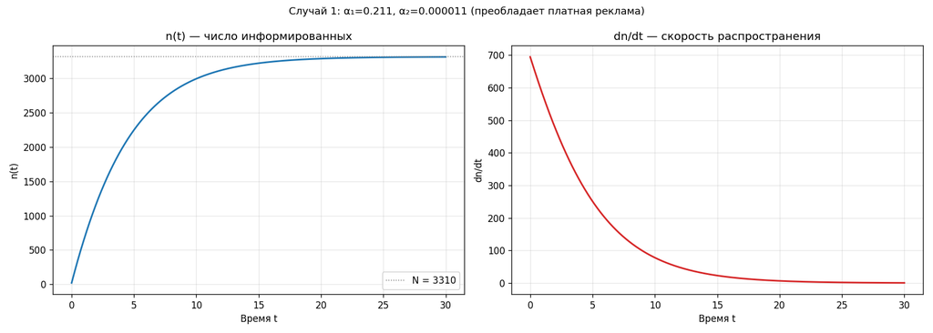

## Случай 1: интерпретация

- $\alpha_1 = 0.211$ доминирует, член $\alpha_2 n$ почти не влияет
- $n(t)$ плавно растёт по экспоненте к насыщению
- $dn/dt$ монотонно убывает от $\approx 700$ до 0
- Насыщение ($n = N = 3310$) за $\sim 25$ единиц времени
- Это **модель Мальтуса** с ограничением

## Случай 2: $\alpha_1 \ll \alpha_2$

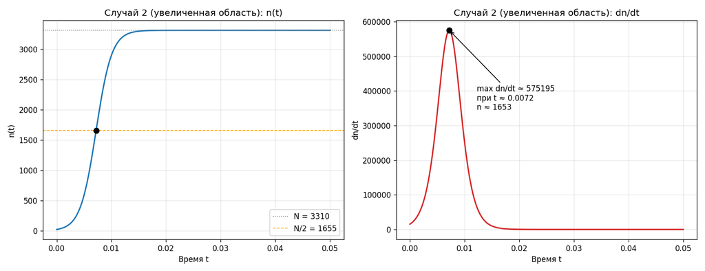

## Случай 2: интерпретация

- $\alpha_2 = 0.21$ доминирует — классическая **логистическая кривая**
- S-образная форма, симметричная относительно точки перегиба
- Насыщение очень быстрое — за $\sim 0.02$ ед. времени
- Максимум скорости $dn/dt$ при $n = N/2$

## Момент максимальной скорости (случай 2)

- Теоретически: $n^{*} = N/2 = 1655$
- Численно: $t^{*} \approx 0.0072$, $n(t^{*}) \approx 1653$
- $\left.\dfrac{dn}{dt}\right|_{t^{*}} \approx 5.75 \cdot 10^{5}$
- Совпадение с теорией с точностью $\sim 0.1\,\%$

## Случай 3: периодические коэффициенты

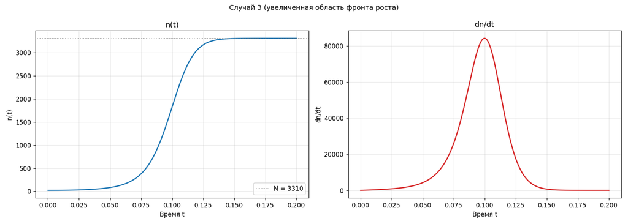

## Случай 3: интерпретация

- На полуволне $\sin(t) > 0$ оба коэффициента положительны
- За первую полуволну $n(t)$ успевает выйти на $N$
- После выхода на $N$ множитель $(N - n) = 0$, динамика «замирает»
- Дальнейшие колебания $\sin(t)$ не выводят систему из насыщения

## Сравнение трёх случаев

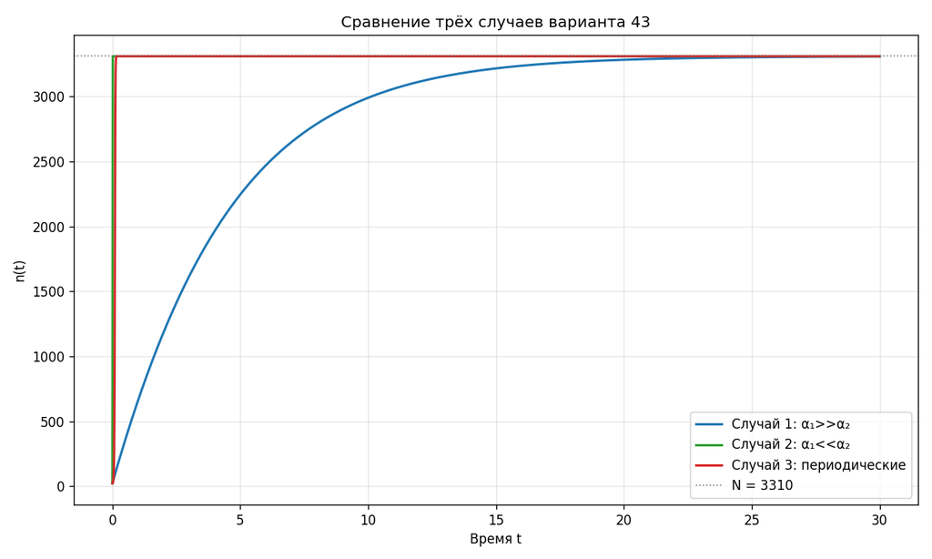

## Платная реклама vs «сарафан»

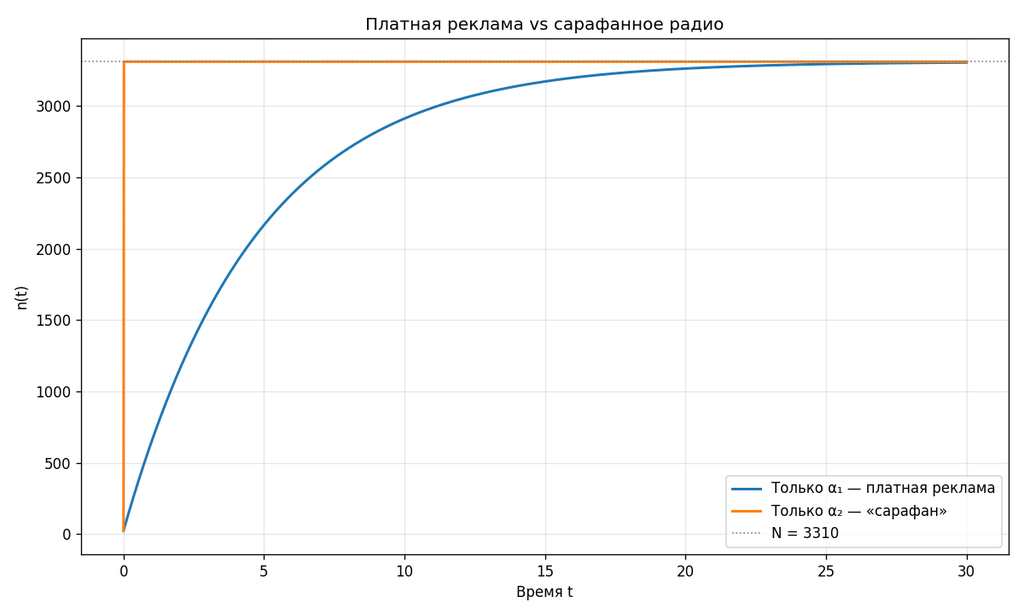

## Сравнение: интерпретация

- При только $\alpha_1$ — медленный экспоненциальный выход за $\sim 30$
- При только $\alpha_2$ — быстрый логистический выход за $\sim 0.02$
- Вирусное распространение **на порядки** быстрее платного
- Эффективна комбинация: $\alpha_1$ для «затравки», $\alpha_2$ для масштабирования

# Итоги

## Выводы

- Реализована модель распространения рекламы методом Tsit5
- Случай 1: модель Мальтуса с насыщением (медленное)
- Случай 2: логистическая кривая, максимум при $n = N/2$
- Случай 3: периодика реализует однопроходную волну роста
- Численный максимум $t^{*}$ совпал с теорией с точностью $0.1\,\%$

## Заключительный слайд

- Скорость распространения рекламы критически зависит от соотношения $\alpha_1$ и $\alpha_2$
- Решающий вклад в насыщение даёт «сарафанное радио»
- Платная реклама даёт необходимую «затравку» при малом начальном $n_0$